# Chapter 3: Sampling the Imaginary

```r
library(rethinking)
library(magrittr)
```

## Easy

Same setup as the globe-tossing example in the chapter

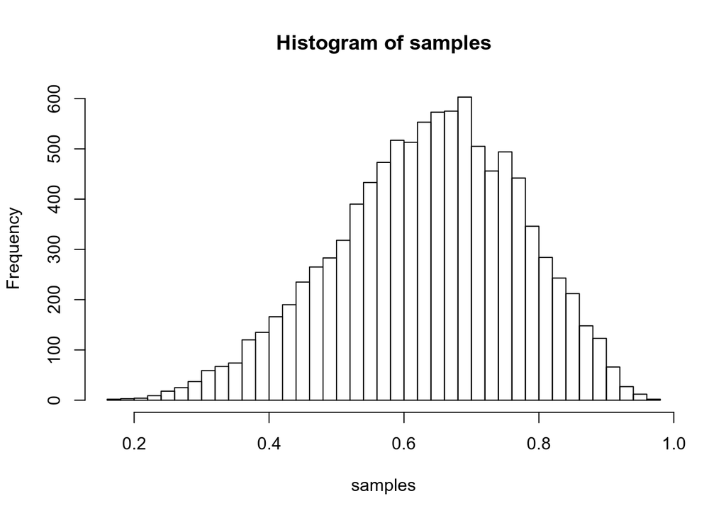

```r
grid_size <- 1000
num_samples <- 1e4
p_grid <- seq(from=0, to=1, length.out=grid_size)
prior <- rep(1, grid_size)

binom_likelihood <- function(prob, trials, successes) {
  # Return vector of likelihood weights corresponding to
  # success probability `prob` given a fixed number of `trials`
  # and `successes`
  return(dbinom(x=successes, size=trials, prob=prob))
}

likelihood <- binom_likelihood(p_grid, 9, 6)  ## example in text
posterior <- prior * likelihood
posterior <- posterior / sum(posterior)

set.seed(100)
samples <- sample(p_grid, prob=posterior, size=num_samples, replace=TRUE)
hist(samples, breaks=50)
```

### 3E1

How much posterior probability lies below $p = 0.2$?

```r
mean(samples < 0.2)
```

```
## [1] 5e-04
```

### 3E2

How much posterior probability lies above $p = 0.8$?

```r
mean(samples > 0.8)
```

```
## [1] 0.1117
```

### 3E3

How much posterior probability lies between $p = 0.2$ and $p = 0.8$?

```r
mean(samples >= 0.2 & samples <= 0.8)
```

```
## [1] 0.8878
```

### 3E4

20% of the posterior probability lies below which value of $p$?

```r
quantile(samples, probs=0.2)
```

```
##       20%
## 0.5195195
```

### 3E5

20% of the posterior probability lies above which value of $p$?

```r
quantile(samples, probs=0.8)
```

```
##       80%
## 0.7567568
```

### 3E6

What is the narrowest 66% interval for the posterior probability?

```r
HPDI(samples, prob=0.66)
```

```
##     |0.66     0.66|
## 0.5205205 0.7847848
```

### 3E7

What is the 66% interval that has the same probability above and below it?

```r
PI(samples, prob=0.66)  ## using the function in rethinking
```

```
##       17%       83%
## 0.5005005 0.7687688
```

```r
prob_tail = (1 - 0.66) / 2
quantile(samples, probs=c(prob_tail, 1-prob_tail)) ## using base functions
```

```
##       17%       83%
## 0.5005005 0.7687688
```

## Medium

### 3M1

Suppose the sequence was 8 water in 15 tosses. Construct the posterior starting from the same prior.

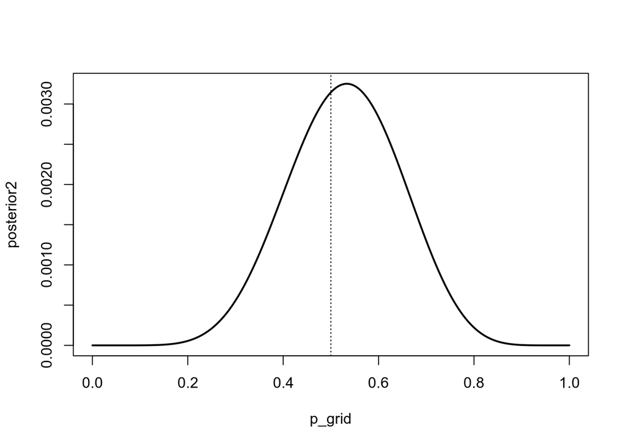

```r
likelihood2 = binom_likelihood(prob=p_grid, trials=15, successes=8)
posterior2 = prior * likelihood2
posterior2 = posterior2 / sum(posterior2)
plot(p_grid, posterior2, type='l', lwd=2)
abline(v=0.5, lty=3)
```

### 3M2

Draw 10^{4} samples from this new distribution. What is the 90% HPDI for p?

```r
samples2 = sample(p_grid, size=num_samples, prob=posterior2, replace=TRUE)
HPDI(samples2, .9)
```

```
##      |0.9      0.9|
## 0.3383383 0.7317317
```

### 3M3

Construct a posterior predictive check from this model. What is the probability of observing 8 water in 15 tosses?

```r
water_in_15 = rbinom(n=num_samples, size=15, prob=samples2)
mean(water_in_15 == 8)
```

```
## [1] 0.1428
```

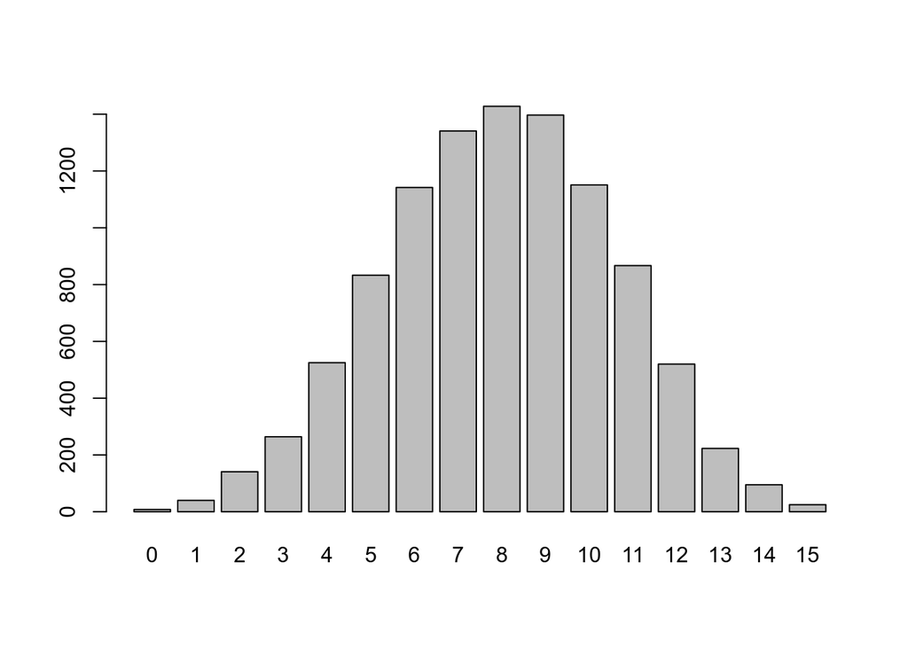

```r
water_in_15 %>% table %>% barplot
```

### 3M4

Keeping the posterior from the 8 out of 15 data, calculate the probabilty of observing 6 water in 9 tosses.

```r
water_in_9 = rbinom(n=num_samples, size=9, prob=samples2)
mean(water_in_9 == 6)
```

```
## [1] 0.1695
```

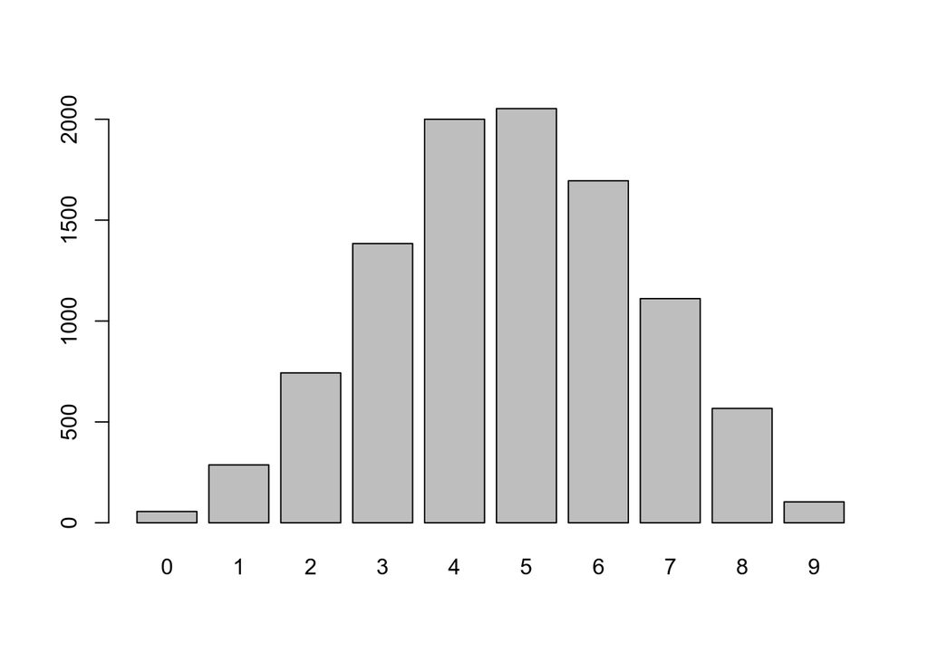

```r
water_in_9 %>% table %>% barplot
```

### 3M5

Repeat 3M1 - 3M4 starting from a prior that is 0 below $p = 0.5$ and constant otherwise.

```r
# define new prior
prior3 = ifelse(p_grid < 0.5, 0, 1)
rle(prior3)  ## checking, should be two chunks of 500
```

```
## Run Length Encoding
##   lengths: int [1:2] 500 500
##   values : num [1:2] 0 1
```

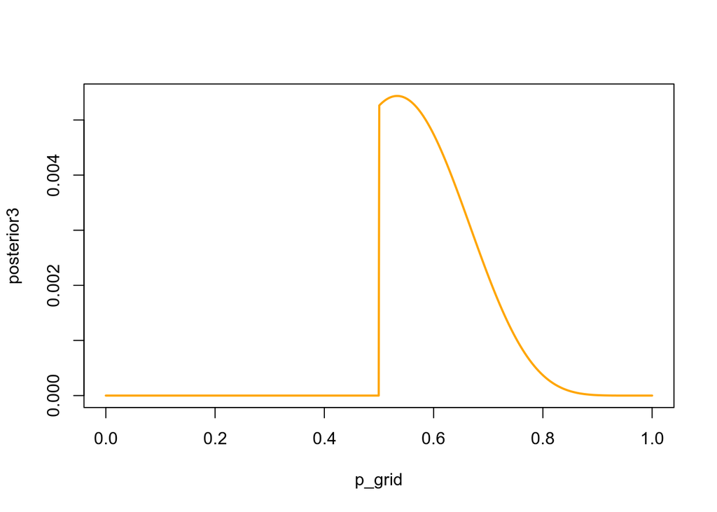

```r
# get new posterior
posterior3 = prior3 * likelihood2
posterior3 = posterior3 / sum(posterior3)
plot(p_grid, posterior3, type='l', lwd=2, col='orange')
```

```r
# get samples of p and the 90% highest posterior density interval
samples3 = sample(p_grid, size=num_samples, prob=posterior3, replace=TRUE)
HPDI(samples3, prob=0.9)
```

```
##      |0.9      0.9|
## 0.5005005 0.7097097
```

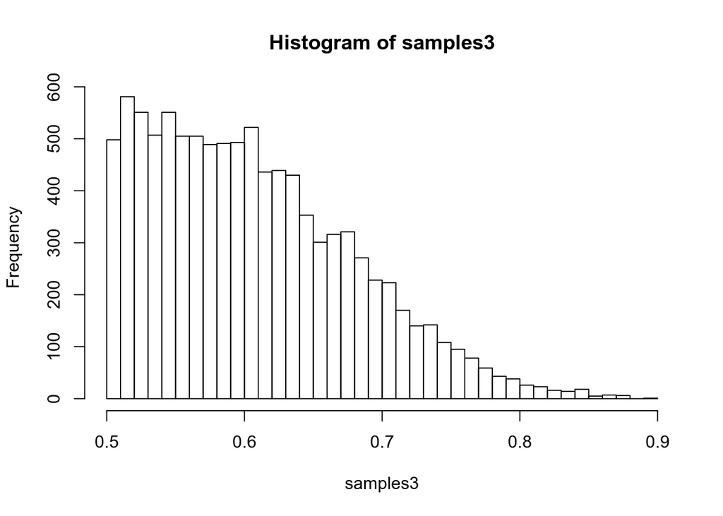

```r
hist(samples3, breaks=50)
```

```r
# what's the chance of getting 8 water in 15 tosses from generated data?
water_in_15_new = rbinom(n=num_samples, size=15, prob=samples3)
mean(water_in_15_new == 8)
```

```
## [1] 0.1592
```

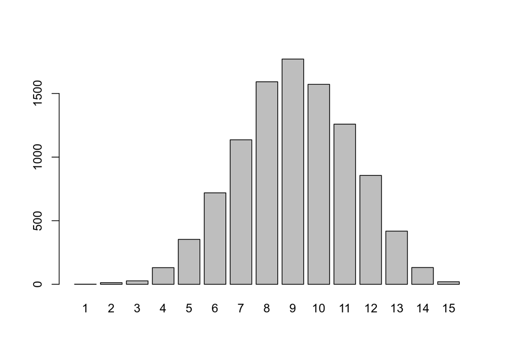

```r
water_in_15_new %>% table %>% barplot
```

```r
# what's the chance of getting 6 water in 9 using the same distro for p?
water_in_9_new = rbinom(n=num_samples, size=9, prob=samples3)
mean(water_in_9_new == 6)
```

```
## [1] 0.2357
```

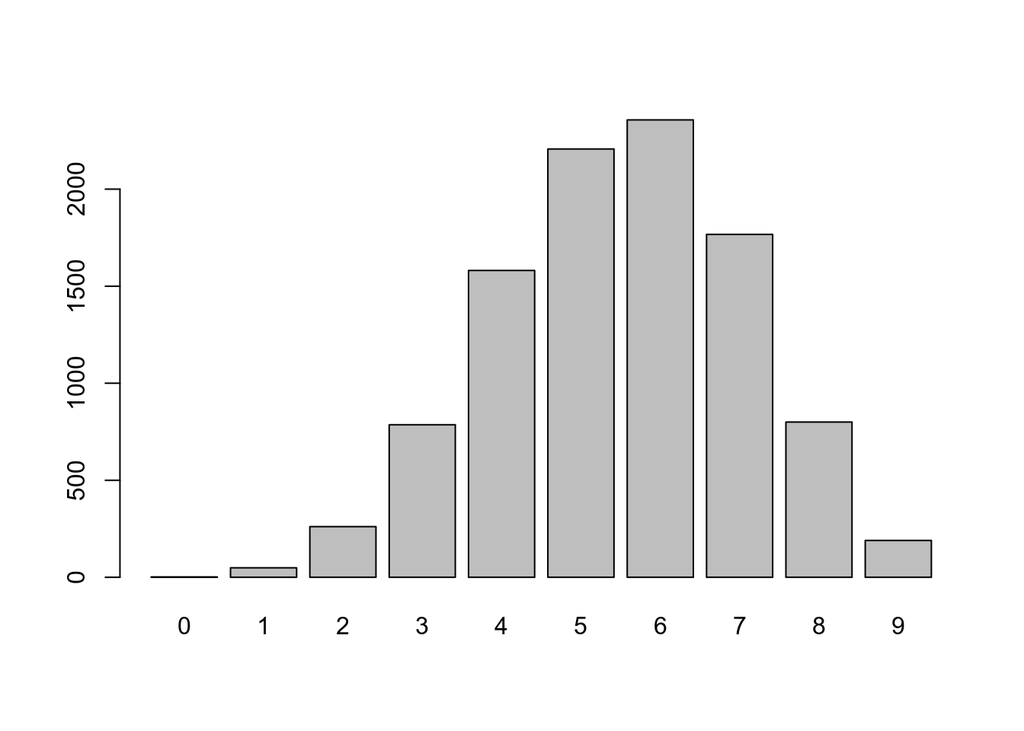

```r
water_in_9_new %>% table %>% barplot
```